# Predicting Real-World Arm Use After Stroke

From Clinical Data to Smart Models

Asad NADEEM

April 19, 2026

# Predicting Real-World Arm Use After Stroke

From Clinical Data to Smart Models

Asad NADEEM

Master STAPS — Sciences Technologies Mouvement  
EuroMov Digital Health in Motion, University of Montpellier  
Course: **Python-R-Git**  
Supervisors: Karima BAKHTI (PhD), Makii MUTHALIB (PhD), Nicolas SUTTON-CHARANI (PhD)  
GitHub: github.com/asadazizmughal/predicting-arm-use-stroke  
Date: April 19, 2026

## Abstract

**Keywords:** stroke, learned non-use, accelerometry, machine learning, cross-validation, LOOCV.

# 1 Introduction

Stroke is the leading cause of acquired disability in adults, with 130,000 new cases each year in France alone (Benjamin et al., 2017). About $77\%$ of patients present upper-limb motor deficits in the acute phase (Lawrence et al., 2001). Recovery trajectories vary: six months after stroke, $49\%$ of patients recover good motor function, $24\%$ retain moderate sequelae, and $27\%$ severe impairment (Vliet et al., 2020). Greater sensorimotor impairment is associated with lower arm use in daily life (Lin et al., 2009), but motor recovery alone does not guarantee spontaneous use.

A subset of patients with good motor recovery still do not spontaneously use their paretic arm — a phenomenon termed *learned non-use* (Taub et al., 2006; Hirsch et al., 2021). Early movement attempts are often clumsy or painful; the patient avoids the affected limb and compensates with the non-affected limb or the trunk. Over time this avoidance becomes automatic and persists even after motor recovery.

Real-world arm use can now be quantified with wrist accelerometers and algorithms that count *functional* movements while filtering passive motion (Leuenberger et al., 2017; Smith & Lang, 2019). The ratio of functional movements between the paretic and non-paretic arm — the $\text{funcUseRatio}$ — provides a normalised within-subject measure of daily use.

The master’s thesis of Le Perf (2022), conducted in our laboratory on 24 patients from the ReArm protocol, found that the Box and Block Test (BBT) alone explained $54\%$ of the variance in $\text{funcUseRatio}$ using a Gamma GLM. The Proximal Arm Non-Use (PANU) measure of trunk compensation during reaching (Bakhti et al., 2017) was not a significant predictor. The present project extends that work on a larger sample ($n = 30$) using supervised machine learning and a patient-level discrepancy analysis to identify learned non-use candidates.

## 1.1 Research Question

> **Can clinical motor and functional tests predict how much stroke patients use their paretic arm in daily life at home? Can we identify specific patients who underuse their arm relative to their motor capacity?**

## 1.2 Objectives

The **technical objective** is to build a reproducible analysis pipeline combining Python (for the machine learning components) and R (for statistical validation and dynamic reporting), hosted on a public GitHub repository. The **scientific objectives** are threefold: (i) identify the clinical predictors of real-world arm use; (ii) compare supervised learning models via Leave-One-Out Cross-Validation (LOOCV); and (iii) detect learned non-use candidates at the individual patient level through a discrepancy analysis.

# 2 Data

## 2.1 Source and Participants

The data originate from the ReArm randomised controlled trial (Muller et al., 2021; ClinicalTrials.gov NCT04291573), investigating tDCS combined with virtual reality therapy for upper-limb recovery. Thirty chronic post-stroke patients were included (21 male, 9 female; mean age $63.7 \pm 12.6$ years; range 33–82; 17 left-paretic, 13 right-paretic). Inclusion required adult patients, $>3$ months post-stroke, with a Fugl-Meyer Upper Extremity score above 15. Patients with cognitive impairments or spatial neglect were excluded.

## 2.2 Clinical Variables

Six continuous and two categorical variables were retained:

- **FMUE_TOTAL** ($/66$) — Fugl-Meyer Upper Extremity, gold standard for motor impairment (Gladstone et al., 2002).
- **WMFT_Total** ($/75$) — Wolf Motor Function Test, 17 timed functional tasks (Nijland et al., 2010).
- **BBT_P** — Box and Block Test (paretic hand), gross manual dexterity (Platz et al., 2005).
- **Barthel** ($/100$) — independence in daily living (Mahoney & Barthel, 1965).
- **PANU** ($\%$) — trunk compensation during reaching; threshold $6.5\%$ indicates proximal non-use (Bakhti et al., 2017).
- **Age**, **Sex**, **Paresis side** — demographics.

## 2.3 Target Variable

Patients wore AX3 accelerometers (Axivity, UK) on both wrists for seven consecutive days at 50 Hz. Daily counts of functional arm movements were computed using the Leuenberger et al. (2017) algorithm (amplitude $>30°$, within $\pm 30°$ of horizontal, 2-second windows). This filtering excludes passive motion such as arm swing during walking. The target is:

$$\text{funcUseRatio} \;=\;
\frac{\overline{\text{FuncUse}}_{\text{paretic}}}{\overline{\text{FuncUse}}_{\text{non-paretic}}}$$

A ratio of $1.0$ indicates symmetric use; lower values indicate under-use of the paretic arm.

## 2.4 Missing Values

PANU was missing for 3 patients ($10\%$) and Barthel for 2 ($7\%$). Both were imputed with the median **inside each cross-validation fold** (training set only) to prevent data leakage, following Prof. Gérard Dray’s (IMT Mines Alès) recommendation. Non-paretic grip force ($63\%$ missing) was dropped.

# 3 Methods

## 3.1 Technical Architecture

The pipeline is split across two languages to exploit the strengths of each:

- **Python** (`main.ipynb`): data loading via `openpyxl` (over `pandas.read_excel`, due to header formatting issues in the source Excel), target computation using `numpy`, ML pipeline with `scikit-learn`, feature importance, and discrepancy analysis. Results saved to `results/`.
- **R** (`main.Rmd`): statistical validation (Shapiro-Wilk, Spearman, Mann-Whitney) and diagnostic plots.

Python produces the merged dataset, R validates it — one-way flow, single source of truth.

## 3.2 Statistical Analysis (R)

The Shapiro-Wilk test confirmed that $\text{funcUseRatio}$ is not normally distributed ($p < 0.05$), with a clear right skew (mean $>$ median). Consequently, we used **non-parametric methods** throughout: Spearman rank correlation ($\rho$) for pairwise associations with the target, and Mann-Whitney $U$ tests for comparing $\text{funcUseRatio}$ between groups defined by Sex and Paresis side. Significance was evaluated at $\alpha = 0.05$.

## 3.3 Machine Learning Pipeline (Python)

### 3.3.1 Feature Set

Eight features were retained: six continuous (PANU, FMUE_TOTAL, WMFT_Total, BBT_P, Barthel, Age) and two binary-encoded categorical (Sex: male = 1; Paresis side: left = 1).

### 3.3.2 Leave-One-Out Cross-Validation with In-Fold Imputation

Given the small sample ($n = 30$), a conventional train/test split leaves too few test patients. We use LOOCV: the model trains on 29 patients and tests on 1, rotating 30 times so every patient receives one held-out prediction. Within each fold:

1. Medians are computed from the **29 training patients only** and used to impute both sets.
2. A `StandardScaler` is fitted on training data only and applied to both.
3. Each model is instantiated fresh using `sklearn.base.clone()` to prevent carry-over.
4. The model is fitted on training data and predicts the test patient.

This rigorously enforces train/test independence.

### 3.3.3 Models Compared

- **Linear Regression** — baseline, no regularisation. With 8 features on 30 patients, prone to overfit.
- **Ridge** ($\alpha = 1.0$) — $\ell_2$ penalty $\lambda \sum \beta_j^2$, stabilises coefficients under multicollinearity.
- **Lasso** ($\alpha = 0.01$, `max_iter=10000`) — $\ell_1$ penalty $\lambda \sum |\beta_j|$, performs automatic feature selection.

### 3.3.4 Evaluation Metrics

MAE, RMSE, and cross-validated $R^2$ computed on all 30 LOOCV predictions:

$$R^2_{CV} = 1 - \frac{\sum_i (y_i - \hat{y}_i)^2}{\sum_i (y_i -
\bar{y})^2}$$

A negative $R^2_{CV}$ means the model predicts worse than the sample mean.

## 3.4 Discrepancy Analysis

For each patient: $\text{Residual}_i = \text{funcUseRatio}_{\text{actual},i} - \text{funcUseRatio}_{\text{predicted},i}$.

Patients with residuals below $-0.05$ use their arm substantially less than their motor scores predict — candidates for **learned non-use** who might benefit from behavioural rather than motor interventions.

# 4 Results

## 4.1 Descriptive Statistics

Table 1. Descriptive statistics of continuous variables (n = 30).

|  | Variable | N | Mean | SD | Median | Min | Max |
| --- | --- | --- | --- | --- | --- | --- | --- |
| Age | Age | 30 | 63.70 | 12.55 | 64.50 | 33.00 | 82.00 |
| PANU | PANU | 27 | 6.30 | 7.40 | 3.00 | 0.00 | 29.00 |
| Barthel | Barthel | 28 | 88.21 | 15.29 | 90.00 | 25.00 | 100.00 |
| FMUE_TOTAL | FMUE_TOTAL | 30 | 44.37 | 15.42 | 48.00 | 15.00 | 66.00 |
| WMFT_Total | WMFT_Total | 30 | 51.83 | 18.26 | 56.50 | 8.00 | 75.00 |
| BBT_P | BBT_P | 30 | 27.10 | 18.52 | 30.00 | 0.00 | 57.00 |
| funcUseRatio | funcUseRatio | 30 | 0.25 | 0.22 | 0.18 | 0.03 | 1.03 |

The sample covers the full range of motor severity (FMUE $15$–$66$). Barthel is high (mean $88.2$), indicating most patients are largely independent. The $\text{funcUseRatio}$ has mean $0.25$, median $0.18$ — patients use their paretic arm about four times less than the non-paretic arm.

## 4.2 Distribution of the Target Variable

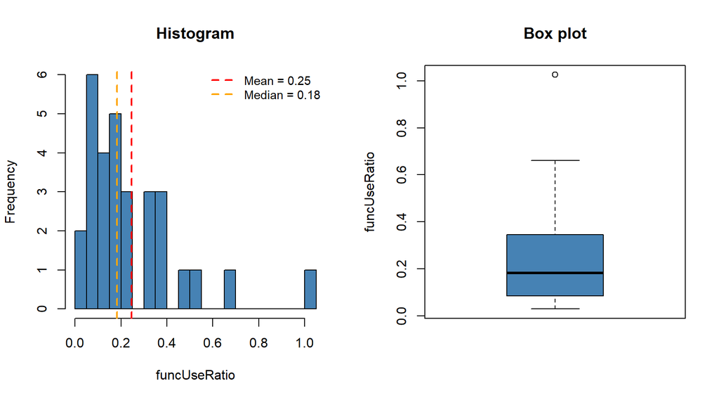

Figure 1. Distribution of funcUseRatio. Left: histogram with mean (red dashed) and median (orange dashed). Right: box plot highlighting the right skew and a high outlier (patient C1P01).

The distribution is right-skewed (Shapiro-Wilk $p = 10^{-4}$; mean $>$ median). Patient C1P01 is a clear outlier with $\text{funcUseRatio} > 1$ — they use their paretic arm *more* than the non-paretic arm, an unusual pattern. Non-normality justifies Spearman correlations.

## 4.3 Correlations with funcUseRatio

Table 2. Spearman correlations with funcUseRatio.

| Variable | rho | p_value | Significance |
| --- | --- | --- | --- |
| WMFT_Total | 0.597 | 0.0005 | *** |
| BBT_P | 0.576 | 0.0009 | *** |
| FMUE_TOTAL | 0.476 | 0.0078 | ** |
| Barthel | 0.358 | 0.0618 | ns |
| PANU | -0.155 | 0.4402 | ns |
| Age | -0.033 | 0.8618 | ns |

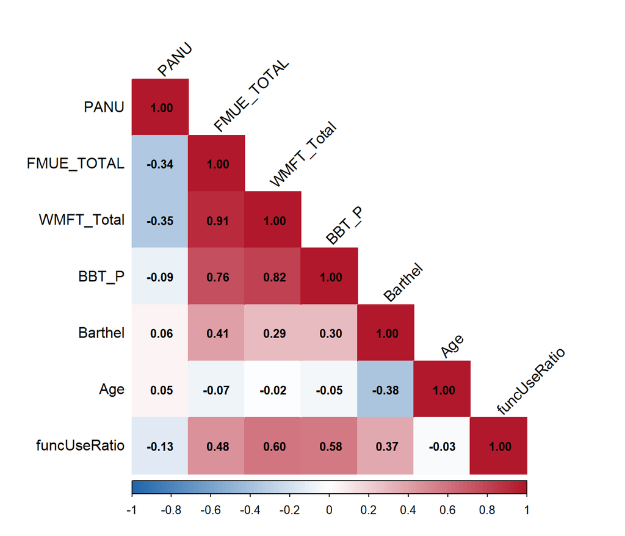

Figure 2. Spearman correlation matrix showing strong multicollinearity between motor tests (FMUE–WMFT ρ = 0.91).

The matrix reveals strong multicollinearity: FMUE–WMFT $\rho = 0.91$, WMFT–BBT $\rho = 0.82$, FMUE–BBT $\rho = 0.76$. Ordinary regression is unstable under such collinearity, justifying Ridge and Lasso. Mann-Whitney tests showed no effect of Sex or Paresis side ($p > 0.05$).

## 4.4 Model Comparison

Table 3. LOOCV model performance. Lower MAE/RMSE and higher R² are better.

| Model | MAE | RMSE | CV_R2 |
| --- | --- | --- | --- |
| Lasso (alpha=0.01) | 0.1619 | 0.2180 | -0.0474 |
| Ridge (alpha=1.0) | 0.1718 | 0.2261 | -0.1266 |
| Linear Regression | 0.1820 | 0.2328 | -0.1936 |

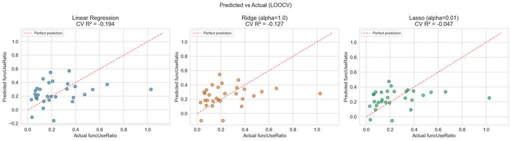

Figure 3. Predicted vs actual funcUseRatio across the three models. The red dashed line represents perfect prediction.

## 4.5 Feature Importance

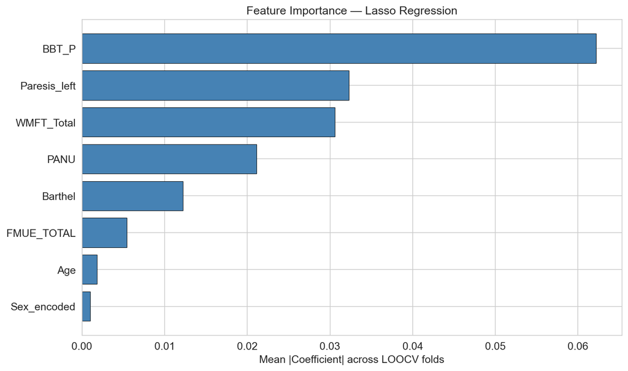

Figure 4. Lasso feature importance: mean absolute coefficient across LOOCV folds.

## 4.6 Discrepancy Analysis

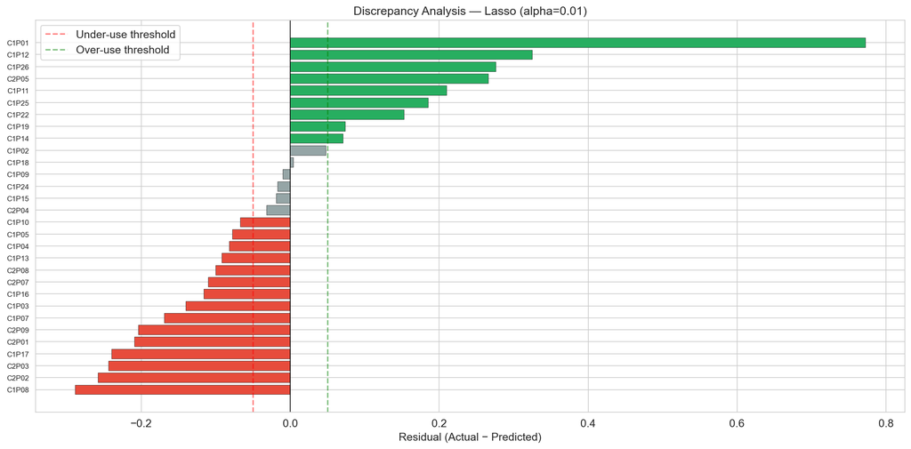

Figure 5. Residuals per patient, sorted. Red = under-use; green = over-use relative to model prediction.

About half of the patients show residuals below $-0.05$, meaning they use their paretic arm less than their clinical scores would predict. These are **learned non-use candidates** — motor capacity looks sufficient but real-world behaviour falls short. Patients with large positive residuals likely benefit from strong motivation or favourable environments.

# 5 Discussion

The present results confirm and extend Le Perf (2022). Motor function tests — particularly WMFT, BBT, and FMUE — are the strongest correlates of real-world arm use. PANU does not predict home arm use in our sample: it measures trunk compensation during one laboratory reaching task, whereas $\text{funcUseRatio}$ reflects cumulative use across all daily activities over seven days. The narrow specificity of PANU limits its ecological validity.

The **discrepancy analysis** operationalises learned non-use as a clinical tool. Rather than a single aggregate statistic, it flags specific patients whose residual under-use may respond to behavioural or motivational interventions (Wei et al., 2019) rather than more motor training. This extends Le Perf (2022), which used group-level regression, to the individual patient level.

## 5.1 Limitations

The sample size ($n = 30$) is small and constrains model complexity. The retained outlier (C1P01, $\text{funcUseRatio} > 1$) may influence coefficient estimates; a formal sensitivity analysis with and without this patient would strengthen the conclusions. The Leuenberger algorithm captures gross functional movements in a restricted spatial zone and may undercount fine motor activities such as typing or writing. Most importantly, no psychosocial variables were available in the ReArm dataset, which prevented us from directly testing the hypothesis that psychological factors explain the residual variance.

## 5.2 Perspectives

Future work should integrate psychosocial assessments (self-efficacy scales, motivation questionnaires, attention tests), engineer richer features from the raw accelerometry (time-series patterns, inter-arm coordination), and employ nested cross-validation for unbiased hyperparameter tuning. A direct comparison with the Gamma GLM of Le Perf (2022) would provide a valuable methodological benchmark.

# 6 Technical Contribution

This project demonstrates a reproducible pipeline:

- **Python (`main.ipynb`)** handles the ML workflow using `scikit-learn`, with explicit technical choices: `openpyxl` for robust Excel parsing, `numpy` for vectorised computation, `sklearn.base.clone()` to prevent cross-fold contamination, and strict training-set-only imputation and scaling (Prof. Dray’s recommendation).
- **R (`main.Rmd`)** provides statistical validation: Shapiro-Wilk normality, Spearman correlations, Mann-Whitney tests, and diagnostic plots. It reads the merged dataset produced by Python.
- **GitHub** hosts the public repository with a feature-branch workflow, explicit `README.md`, and MIT licence.
- **R Markdown** generates this report dynamically: re-running the pipeline and re-knitting updates all tables and figures automatically.

# References

Bakhti, K. K. A., Mottet, D., Schweighofer, N., Froger, J., & Laffont, I. (2017). Proximal arm non-use when reaching after a stroke. *Neuroscience Letters*, 657, 91–96.

Ballester, B. R., Maier, M., et al. (2016). Counteracting learned non-use in chronic stroke patients with reinforcement-induced movement therapy. *Journal of NeuroEngineering and Rehabilitation*, 13(1), 74.

Ballester, B. R., Winstein, C., & Schweighofer, N. (2022). Virtuous and vicious cycles of arm use and function post-stroke. *Frontiers in Neurology*, 13, 804211.

Benjamin, E. J., Blaha, M. J., et al. (2017). Heart disease and stroke statistics — 2017 update. *Circulation*, 135(10).

Gladstone, D. J., Danells, C. J., & Black, S. E. (2002). The Fugl-Meyer Assessment of motor recovery after stroke. *Neurorehabilitation and Neural Repair*, 16(3), 232–240.

Hirsch, T., Barthel, M., et al. (2021). A first step toward the operationalization of the learned non-use phenomenon. *Neurorehabilitation and Neural Repair*, 35(5), 383–392.

Lawrence, E. S., Coshall, C., et al. (2001). Estimates of the prevalence of acute stroke impairments and disability. *Stroke*, 32(6), 1279–1284.

Le Perf, G. (2022). *Expliquer l’utilisation au quotidien du membre supérieur parétique après accident vasculaire cérébral*. Master’s thesis, University of Montpellier.

Leuenberger, K., Gonzenbach, R., et al. (2017). A method to qualitatively assess arm use in stroke survivors. *Medical & Biological Engineering & Computing*, 55(1), 141–150.

Lin, K., Huang, Y., Hsieh, Y., & Wu, C. (2009). Potential predictors of motor and functional outcomes after distributed constraint-induced therapy. *Neurorehabilitation and Neural Repair*, 23(4), 336–342.

Mahoney, F. I., & Barthel, D. W. (1965). Functional evaluation: The Barthel Index. *Maryland State Medical Journal*, 14, 61–65.

Muller, C. O., Muthalib, M., et al. (2021). Recovering arm function in chronic stroke patients (ReArm). *Trials*, 22(1), 747.

Nijland, R., van Wegen, E., et al. (2010). A comparison of the WMFT and ARAT. *Journal of Rehabilitation Medicine*, 42(7), 694–696.

Otaki, R., Oouchida, Y., et al. (2022). Relationship between body-specific attention and real-world arm use in stroke. *Frontiers in Systems Neuroscience*, 15, 806257.

Platz, T., Pinkowski, C., et al. (2005). Reliability and validity of the Fugl-Meyer, ARAT and BBT. *Clinical Rehabilitation*, 19(4), 404–411.

Smith, B. A., & Lang, C. E. (2019). Sensor measures of symmetry quantify upper limb movement. *Archives of Physical Medicine and Rehabilitation*, 100(6), 1176–1183.

Stewart, J. C., Lewthwaite, R., et al. (2019). Self-efficacy and reach performance in stroke. *Neurorehabilitation and Neural Repair*, 33(4), 319–328.

Taub, E., Uswatte, G., et al. (2006). The learned nonuse phenomenon. *Europa Medicophysica*, 42(3), 241–255.

Vliet, R., Selles, R. W., et al. (2020). Predicting upper limb motor impairment recovery after stroke: A mixture model. *Annals of Neurology*, 87(3), 383–393.

Wei, W. X. J., Fong, K. N. K., et al. (2019). “Remind-to-Move” for promoting upper extremity recovery using wearable devices in subacute stroke. *IEEE Transactions on Neural Systems and Rehabilitation Engineering*, 27(1), 51–59.

*Report generated on April 19, 2026 using R Markdown.*